# Homework 6

Allie Caughman

## Tree-Based Models

For this assignment, we will continue working with the file `"pokemon.csv"`, found in `/data`. The file is from Kaggle: https://www.kaggle.com/abcsds/pokemon.

The [Pokémon](https://www.pokemon.com/us/) franchise encompasses video games, TV shows, movies, books, and a card game. This data set was drawn from the video game series and contains statistics about 721 Pokémon, or “pocket monsters.” In Pokémon games, the user plays as a trainer who collects, trades, and battles Pokémon to (a) collect all the Pokémon and (b) become the champion Pokémon trainer.

Each Pokémon has a [primary type](https://bulbapedia.bulbagarden.net/wiki/Type) (some even have secondary types). Based on their type, a Pokémon is strong against some types, and vulnerable to others. (Think rock, paper, scissors.) A Fire-type Pokémon, for example, is vulnerable to Water-type Pokémon, but strong against Grass-type.

The goal of this assignment is to build a statistical learning model that can predict the **primary type** of a Pokémon based on its generation, legendary status, and six battle statistics.

**Note: Fitting ensemble tree-based models can take a little while to run. Consider running your models outside of the .Rmd, storing the results, and loading them in your .Rmd to minimize time to knit.**

### Exercise 1

Read in the data and set things up as in Homework 5:

- Use `clean_names()`
- Filter out the rarer Pokémon types
- Convert `type_1` and `legendary` to factors

```r
pokemon = read_csv(here::here("data", "Pokemon.csv")) %>% #load in data
  clean_names() %>%  #lowercase snake case all names
  filter(type_1 %in% c("Bug", "Fire", "Grass", "Normal", "Water", "Psychic")) %>% #filter pokemon to only contain Bug, Fire, Grass, Normal, Water, and Psychic
  mutate(type_1 = as.factor(type_1)) %>% #change type 1 to factor
  mutate(legendary = as.factor(legendary)) %>%  #change legendary to factor
  mutate(generation = as.factor(generation))
```

Do an initial split of the data; you can choose the percentage for splitting. Stratify on the outcome variable.

```r
split = initial_split(pokemon, strata = type_1, prob = .8) #create splitting vector

poke_train = training(split) #get training data
poke_test = testing(split) #get testing data
```

Fold the training set using *v*-fold cross-validation, with `v = 5`. Stratify on the outcome variable.

```r
folds = vfold_cv(poke_train, v = 5, strata = type_1) #create cross validation folds
```

Set up a recipe to predict `type_1` with `legendary`, `generation`, `sp_atk`, `attack`, `speed`, `defense`, `hp`, and `sp_def`:

- Dummy-code `legendary` and `generation`;
- Center and scale all predictors.

```r
poke_recipe = recipe(type_1 ~ legendary + generation + sp_atk + attack + speed + defense + hp + sp_def, data = poke_train) %>% #create model formula
  step_dummy(all_nominal_predictors()) %>% #dummy code categorical predictors
  step_normalize(all_predictors()) #center and scale all predictors
```

### Exercise 2

Create a correlation matrix of the training set, using the `corrplot` package. *Note: You can choose how to handle the continuous variables for this plot; justify your decision(s).*

**Answer:** all numeric variables used in the model are included in the correlation plot.

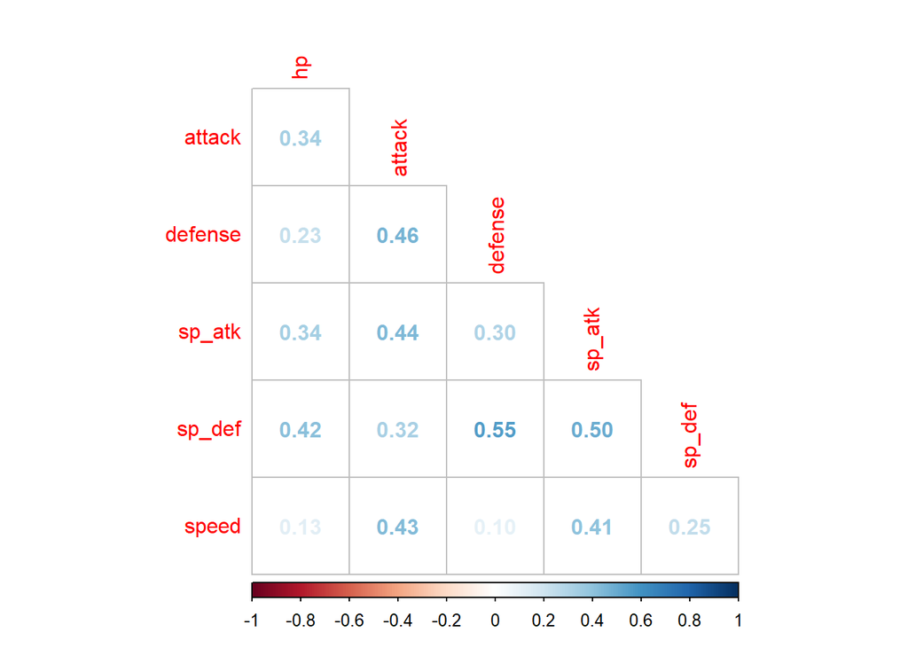

```r
pokemon %>%
  select(where(is.numeric)) %>% #keep all numeric variables
  select(-number, - total) %>% #remove variables not in model
  cor() %>% #calcuate correlations
  corrplot(type = "lower", method = "number", diag = FALSE) #plot correlations with numeric values
```

What relationships, if any, do you notice? Do these relationships make sense to you?

**Answer:** special defense and defense have the highest correlation. Attack and defense are also decently correlated, as well as special attack and special defense. Speed is also quite related to attack which makes sense. In general, more powerful Pokemon have higher values of all metrics so it makes sense they are correlated to an extent. Pokemon also tend to fall into 4 groups: strong in special attack/attack, strong in special defense/defense, strong in regular attack/defense, or strong in special attack/special defense, so the other correlations also make sense.

### Exercise 3

First, set up a decision tree model and workflow. Tune the `cost_complexity` hyperparameter. Use the same levels we used in Lab 7 – that is, `range = c(-3, -1)`. Specify that the metric we want to optimize is `roc_auc`.

```r
tree_model = decision_tree(cost_complexity = tune()) %>% #set decision tree model with cost complexity tuned
  set_engine("rpart") %>% #use r part engine
  set_mode("classification") #set mode to classification

tree_wflw = workflow() %>% #create new workflow
  add_recipe(poke_recipe) %>% #add pokemon recipe
  add_model(tree_model) #add decision tree model

param_grid <- grid_regular(cost_complexity(range = c(-3, -1)), levels = 10) #create cost complexity gride ranged from -3 to -1
```

```r
tree_tune <- tune_grid( #use cross validation to tune cost complexity
  tree_wflw, #add workflow
  resamples = folds, #use cv folds
  grid = param_grid, #add parameter grid from -3 to -1
  metrics = metric_set(roc_auc) #tune based on ROC AUC
)
```

Print an `autoplot()` of the results. What do you observe? Does a single decision tree perform better with a smaller or larger complexity penalty?

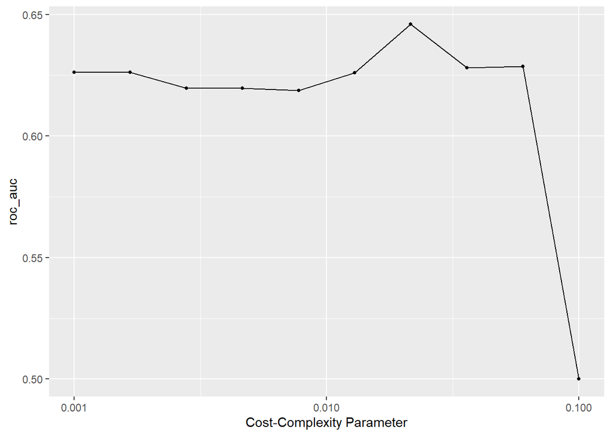

```r
autoplot(tree_tune) #autoplot cost complexity tuning results
```

**Answer:** The decision tree preforms better with smaller complexity penalties. It has a peak at mid level complexity.

### Exercise 4

What is the `roc_auc` of your best-performing pruned decision tree on the folds?

```r
tree_metrics = collect_metrics(tree_tune) %>% #get roc auc of all models
  select(mean) %>% #select only mean
  slice_max(n = 1, order_by = mean) %>%  #get top AUC ROC by mean
  mutate(model = "Decision Tree") #add model name

tree_metrics$mean
```

```
## [1] 0.6459729
```

### Exercise 5

Using `rpart.plot`, fit and visualize your best-performing pruned decision tree with the *training* set.

```r
tree_final = finalize_workflow(tree_wflw, select_best(tree_tune)) #finalize tree model workflow with best complexity penalty parameter

tree_fit = fit(tree_final, poke_train) #fit final tree model to training data
```

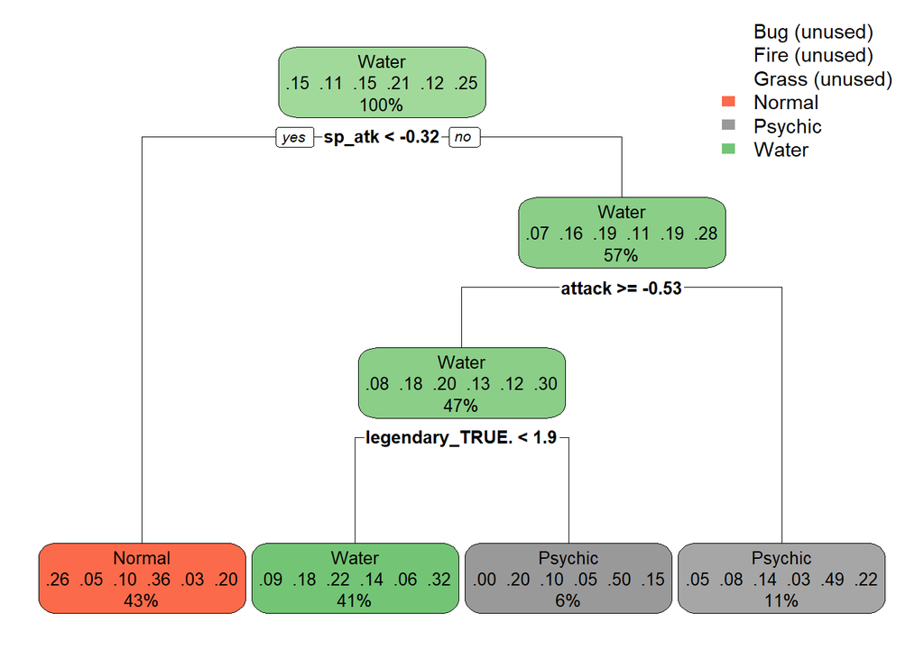

```r
tree_fit %>%
  extract_fit_engine() %>% #extract decision tree information from the fit
  rpart.plot() #plot decision trees
```

### Exercise 5

Now set up a random forest model and workflow. Use the `ranger` engine and set `importance = "impurity"`. Tune `mtry`, `trees`, and `min_n`. Using the documentation for `rand_forest()`, explain in your own words what each of these hyperparameters represent.

```r
rf_model = rand_forest(mtry = tune(), trees = tune(), min_n = tune()) %>% #set random forest model to trun trees, mtry, and min_n parameters
  set_engine("ranger", importance = "impurity") %>% #use ranger engine with importance set as impurity
  set_mode("classification") #set mode as classification

rf_wflw = workflow() %>% #create new workflow
  add_recipe(poke_recipe) %>% #add pokemon recipe
  add_model(rf_model) #add random forest model
```

**Answer:** * mtry = the number of predictors randomly sampled when creating each of the trees in the random forest * trees = the number of individual trees created in the random forest model * min_n = the number of data points included at each node in the decision tree required for the node to continue to be split

Create a regular grid with 8 levels each. You can choose plausible ranges for each hyperparameter. Note that `mtry` should not be smaller than 1 or larger than 8. **Explain why not. What type of model would `mtry = 8` represent?**

```r
rf_grid <- grid_regular(
  mtry(range = c(1, 8)), #set mtry to between 1 and 8
  trees(range = c(10,2000)), #set tress to between 10 and 2000
  min_n(range = c(2, 40)), # set min_n between 2 and 40
  levels = 8) #use 8 levels
```

**Answer:** A model with mtry = 8 represents a random forest where all the trees are identical because they all use all of the predictors in the model.

### Exercise 6

Specify `roc_auc` as a metric. Tune the model and print an `autoplot()` of the results. What do you observe? What values of the hyperparameters seem to yield the best performance?

```r
rf_tune <- tune_grid( #use cross validation to tune mtry, trees, and min_n parameters
  rf_wflw, #add workflow
  resamples = folds, #use cv folds
  grid = rf_grid, #add parameter grid from -3 to -1
  metrics = metric_set(roc_auc) #tune based on ROC AUC
  )
```

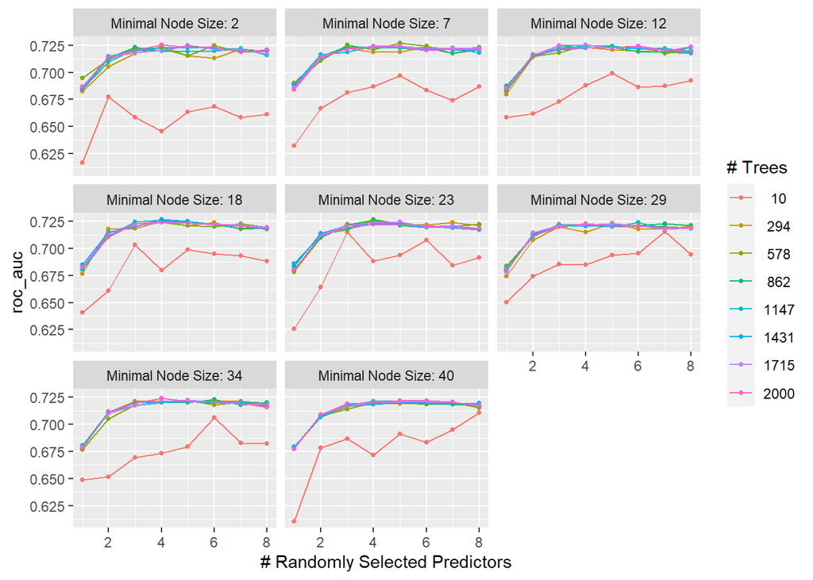

```r
autoplot(rf_tune) #auotplot tuning results
```

**Answer:** Minimal node size seems to have little effect on peak accuracy. In general, having a low number of predictors leads to lower accuracy, and this peaks around 3 predictors. It decreases slightly around 6-8 predictors. Number of trees also has minimal effect on accuracy once you have more than 10 trees in your model. 10 trees has lower accuracy than other combinations.

### Exercise 7

What is the `roc_auc` of your best-performing random forest model on the folds?

```r
rf_metrics = collect_metrics(rf_tune) %>% #get roc auc of all models
  select(mean) %>% #select only mean
  slice_max(n = 1, order_by = mean) %>%  #get top AUC ROC by mean
  mutate(model = "Random Forest") #add model name

rf_metrics$mean
```

```
## [1] 0.7271469
```

### Exercise 8

Create a variable importance plot, using `vip()`, with your best-performing random forest model fit on the *training* set.

```r
rf_final = finalize_workflow(rf_wflw, select_best(rf_tune)) #finalize tree model workflow with best mtry, trees, and min_n parameters

rf_fit = fit(rf_final, poke_train) #fit final tree model to training data
```

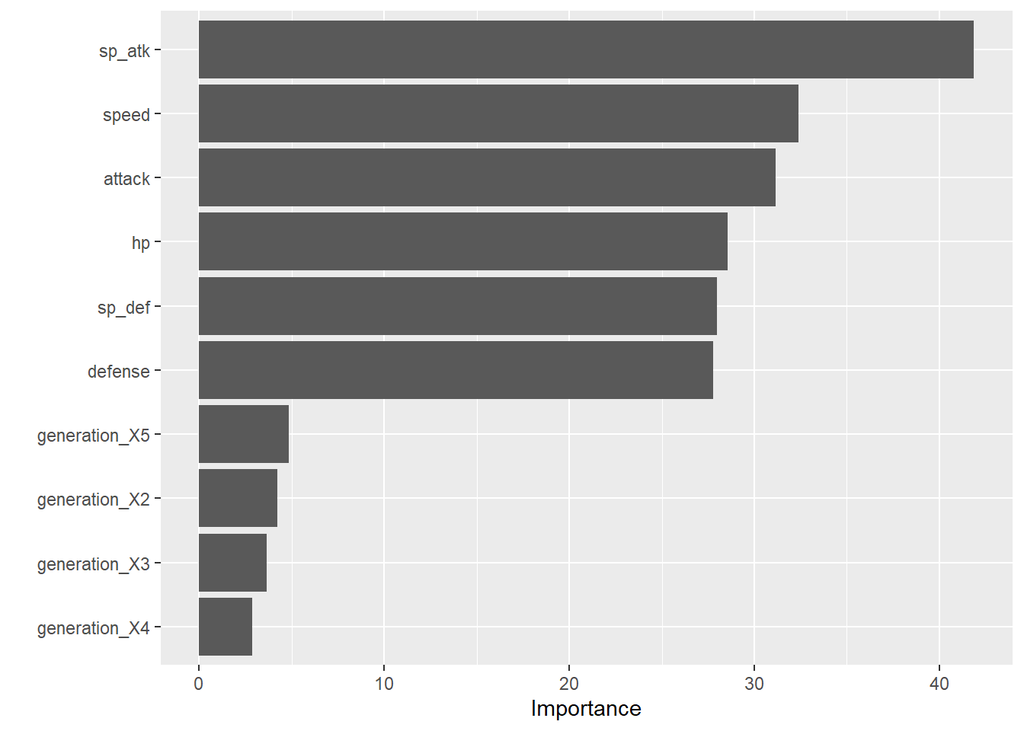

```r
rf_fit %>%
  extract_fit_engine() %>% #extract fit engine
  vip() #visualize the importance of variables
```

Which variables were most useful? Which were least useful? Are these results what you expected, or not?

**Answer:** Special attack is the most important. Speed, attack, hp, special defense, and defense follow with similar levels of importance. Finally, generation and legendary status are the least important variable in the model.

### Exercise 9

Finally, set up a boosted tree model and workflow. Use the `xgboost` engine. Tune `trees`. Create a regular grid with 10 levels; let `trees` range from 10 to 2000. Specify `roc_auc` and again print an `autoplot()` of the results.

```r
boost_model = boost_tree(trees = tune()) %>% #set up boosted tree model
  set_engine("xgboost") %>% #use xgboost engine
  set_mode("classification") #set mode to classification

boost_wflw = workflow() %>% #create new workflow
  add_recipe(poke_recipe) %>% #add pokemon recipe
  add_model(boost_model) #add random forest model
```

```r
boost_grid <- grid_regular(
  trees(range = c(10,2000)), #set tress to between 10 and 2000
  levels = 8) #use 8 levels
```

```r
boost_tune <- tune_grid( #use cross validation to tune trees parameter
  boost_wflw, #add workflow
  resamples = folds, #use cv folds
  grid = boost_grid, #add parameter grid from -3 to -1
  metrics = metric_set(roc_auc) #tune based on ROC AUC
  )
```

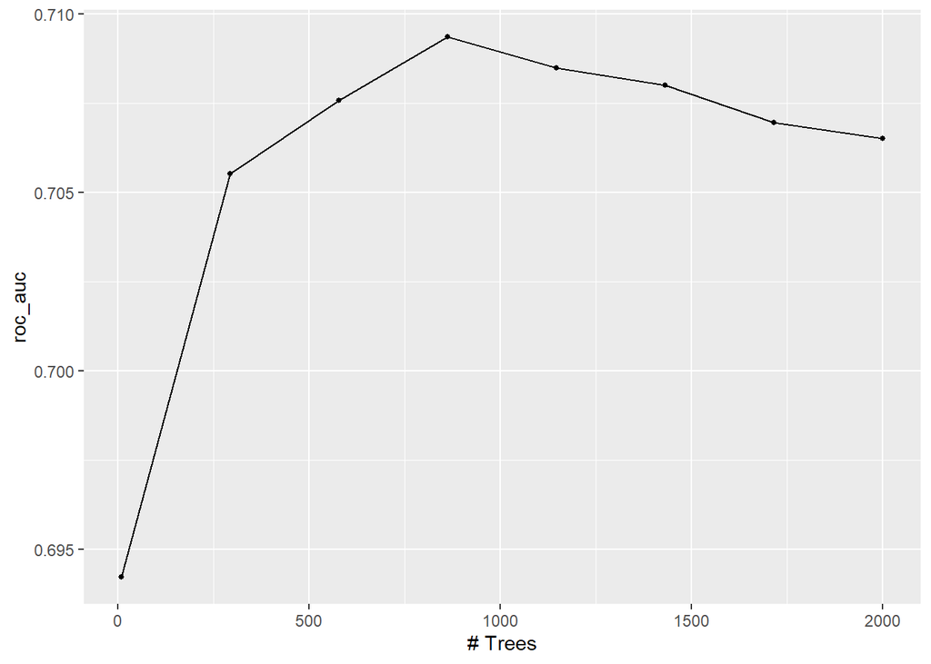

```r
autoplot(boost_tune) #auotplot tuning results
```

What do you observe?

**Answer:** Low number of trees are the least accurate. ROC ACU peaks at around 800 trees and then slowly declines again.

What is the `roc_auc` of your best-performing boosted tree model on the folds?

```r
boost_metrics = collect_metrics(boost_tune) %>% #get roc auc of all models
  select(mean) %>% #select only mean
  slice_max(n = 1, order_by = mean) %>%  #get top AUC ROC by mean
  mutate(model = "Boosted Trees") #Add model name

boost_metrics$mean
```

```
## [1] 0.7093618
```

### Exercise 10

Display a table of the three ROC AUC values for your best-performing pruned tree, random forest, and boosted tree models. Which performed best on the folds? Select the best of the three and use `select_best()`, `finalize_workflow()`, and `fit()` to fit it to the *testing* set.

```r
models = full_join(tree_metrics, rf_metrics)
models = full_join(models, boost_metrics)

models %>%
  kbl(digits = 2, col.names = c("ROC AUC", "Model")) %>%
  kable_minimal()
```

| ROC AUC | Model |
| --- | --- |
| 0.65 | Decision Tree |
| 0.73 | Random Forest |
| 0.71 | Boosted Trees |

**Answer:** The best model is the random forest model, with an AUC ROC of 0.727.

Print the AUC value of your best-performing model on the testing set. Print the ROC curves. Finally, create and visualize a confusion matrix heat map.

```r
rf_test_fit = augment(rf_fit, new_data = poke_test) #get predictions for test data

roc_auc(rf_test_fit, truth = type_1, .pred_Bug, .pred_Fire, .pred_Grass, .pred_Normal, .pred_Water, .pred_Psychic) #print ROC AUC for test data
```

```
## # A tibble: 1 x 3
##   .metric .estimator .estimate
##   <chr>   <chr>          <dbl>
## 1 roc_auc hand_till      0.638
```

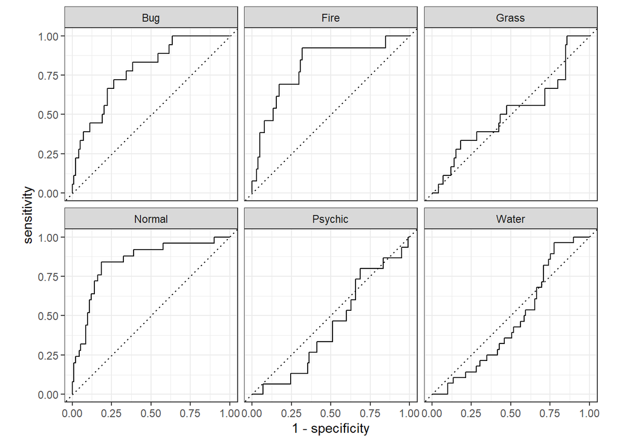

```r
autoplot(roc_curve(rf_test_fit, truth = type_1, .pred_Bug, .pred_Fire, .pred_Grass, .pred_Normal, .pred_Water, .pred_Psychic)) #plot ROC curves for each class
```

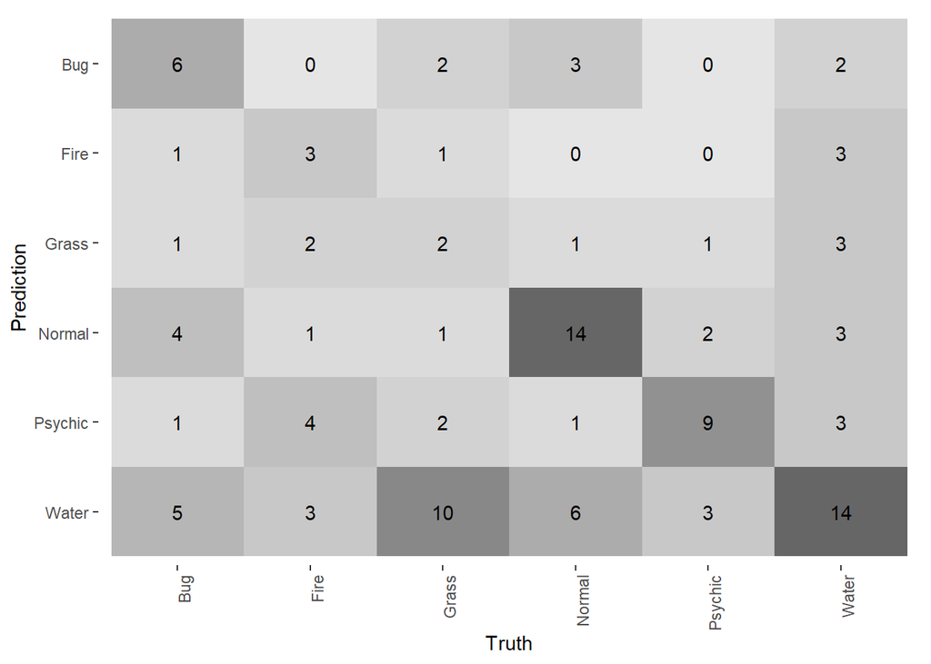

```r
conf_mat(rf_test_fit, truth = type_1, estimate = .pred_class) %>% #calclate confusion matrix
  autoplot(type = "heatmap") + #autoplot with a heatmap
  theme(axis.text.x = element_text(angle = 90, hjust=1)) #rotate x axis labels
```

Which classes was your model most accurate at predicting? Which was it worst at?

## For 231 Students

### Exercise 11

Using the `abalone.txt` data from previous assignments, fit and tune a random forest model to predict `age`. Use stratified cross-validation and select ranges for `mtry`, `min_n`, and `trees`. Present your results. What was the model’s RMSE on your testing set?

```r
abalone_full = read_csv(here::here("data", "abalone.csv")) %>%  #read in data
  mutate(type = as.factor(type)) #turn type into factor

abalone = abalone_full %>%
  mutate(age = 1.5 + rings) #create age from 1.5 + rings

abalone_split = initial_split(abalone, prop = .75, strata = age) #create the split straified by age

abalone_train = training(abalone_split) #get training data
abalone_test = testing(abalone_split) #get testing data

abalone_folds = vfold_cv(abalone_train, v = 5, strata = age) #create cross validation folds

abalone_recipe = recipe(age ~ type + longest_shell + diameter + height + whole_weight + shucked_weight + viscera_weight + shell_weight, data = abalone_train) %>% #start recpite
  step_dummy(all_nominal_predictors()) %>% #1. create dummy variables
  step_interact(terms = ~ type:shucked_weight) %>% #2. add interactions
  step_interact(terms = ~ longest_shell:diameter) %>%
  step_interact(terms = ~ shucked_weight:shell_weight) %>%
  step_center(all_predictors()) %>% #center all predictors
  step_scale(all_predictors()) #scale all predictors

abalone_rf = rand_forest(mtry = tune(), trees = tune(), min_n = tune()) %>% #set random forest model to trun trees, mtry, and min_n parameters
  set_engine("ranger", importance = "impurity") %>% #use ranger engine with importance set as impurity
  set_mode("regression") #set mode as regression

abalone_rf_wflw = workflow() %>% #create new workflow
  add_recipe(abalone_recipe) %>% #add pokemon recipe
  add_model(abalone_rf) #add random forest model

abalone_rf_grid <- grid_regular(
  mtry(range = c(1, 8)), #set mtry to between 1 and 8
  trees(range = c(10,2000)), #set tress to between 1 and 2000
  min_n(range = c(2, 40)), # set min_n between 2 and 40
  levels = 8) #use 8 levels
```

```r
abalone_rf_tune <- tune_grid( #use cross validation to tune mtry, trees, and min_n parameters
  abalone_rf_wflw, #add workflow
  resamples = abalone_folds, #use cv folds
  grid = abalone_rf_grid, #add parameter grid
  metrics = metric_set(rmse) #tune based on ROC AUC
  )
```

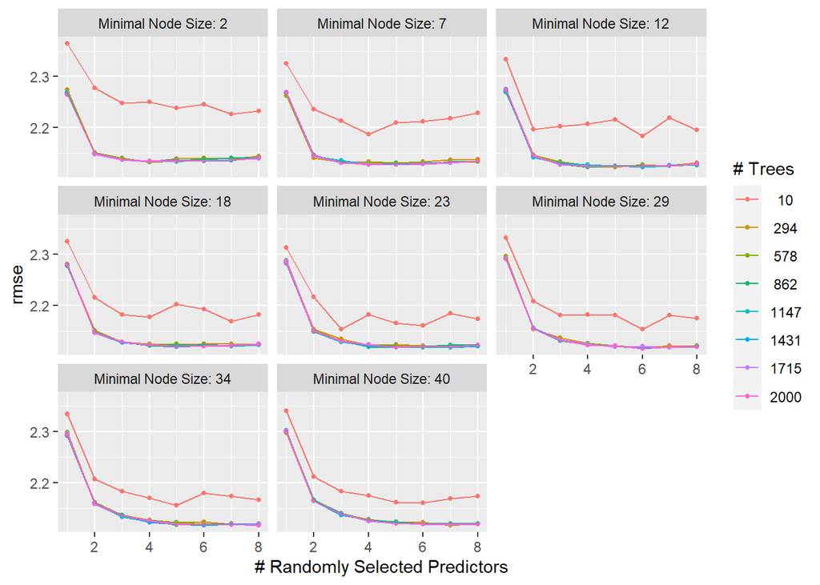

```r
autoplot(abalone_rf_tune) #auotplot tuning results
```

```r
select_best(abalone_rf_tune)
```

```
## # A tibble: 1 x 4
##    mtry trees min_n .config
##   <int> <int> <int> <chr>
## 1     6  2000    29 Preprocessor1_Model382
```

```r
collect_metrics(abalone_rf_tune) %>% #get roc auc of all models
  select(mean) %>% #select only mean
  slice_max(n = 1, order_by = mean) #get top AUC ROC by mean
```

```
## # A tibble: 1 x 1
##    mean
##   <dbl>
## 1  2.36
```

```r
abalone_rf_final = finalize_workflow(abalone_rf_wflw, select_best(abalone_rf_tune)) #finalize tree model workflow with best mtry, trees, and min_n parameters

abalone_rf_fit = fit(abalone_rf_final, abalone_train) #fit final rf model to training data
```

```r
augment(abalone_rf_fit, new_data = abalone_test) %>% #predict on test data
  rmse(truth = age, estimate = .pred) #get rmse for testing set
```

```
## # A tibble: 1 x 3
##   .metric .estimator .estimate
##   <chr>   <chr>          <dbl>
## 1 rmse    standard        2.16
```